# Ml Assignment 1 question 1b

b). Repeat the above experiment but for varying sample sizes in the same ’run’. Specifically, pick m samples as above but the sample sizes are in turn randomly sampled from a Gaussian. Generate plots showing how convergence changes with μ, σ and m where μ, are the mean and variance of the Gaussian from which the sample sizes are picked.

Solution:

```python
import pandas as pd
import numpy as np
import random
import math
import statistics as s
import matplotlib.pyplot as plt
```

Step1: Load the Salary.csv dataset

```python
salary = pd.read_csv(r'/home/kanika/Downloads/Salaries.csv')
salary = salary[['Id','TotalPay']]
#Displaying top 5 rows
salary[:5]
```

|  | Id | TotalPay |
| --- | --- | --- |
| 0 | 1 | 567595.43 |
| 1 | 2 | 538909.28 |
| 2 | 3 | 335279.91 |
| 3 | 4 | 332343.61 |
| 4 | 5 | 326373.19 |

Step2: Calculate the Aggregate function on the entire column 'Total Pay'. The Agggregate function we picked is mean

```python
mean = salary['TotalPay'].mean()
print("Mean of the entire column 'TotalPay' = ",mean)
```

```
Mean of the entire column 'TotalPay' =  74768.3219717
```

To generate random sample size from the gaussian we can use random.randn() function from the numpy library

```python
#sigma * np.random.randn(...) + mu
#mean=1000 and sd =100
n=len(salary['Id'])
S=100 * np.random.randn() +1000
print("The random number generated from the gaussian with mean=1000 and standard deviation=100= ",S)
#Since we nee the size of sample so lets take the ceil of S
S= math.ceil(S)
print("The randomly generated sample size is = ",S)
```

```
The random number generated from the gaussian with mean=1000 and standard deviation=100=  1084.2223622697884
The randomly generated sample size is =  1085
```

Step 4 Randomly (uniform) sample S elements from the dataset:

```python
#using sample function to generate the random number of rows
sample =random.sample(range(n), int(S))
```

```python
# to select the values of the column 'TotalPay' respective to the row numbered sampled above
sampleTotalPay = salary[salary['Id'].isin(sample)]
sampleTotalPay = sampleTotalPay['TotalPay']
```

Step5 Compute the sample statistic τci:

```python
sample_mean =sampleTotalPay.mean()
print("Mean of the sampled data is = ",sample_mean)
```

```
Mean of the sampled data is =  73573.8246267
```

Step6 Repeating step 5 m times : Let m= 100

```python
sampled_mean_vector = []
for i in range(100):
    S=100 * np.random.randn() +1000
    S= math.ceil(S)
    sample =random.sample(range(n), int(S))
    sampleTotalPay = salary[salary['Id'].isin(sample)]
    sampleTotalPay = sampleTotalPay['TotalPay']
    sample_mean =float(sampleTotalPay.mean())
    sampled_mean_vector.append(sample_mean)
print("List of m means is as follows \n",sampled_mean_vector)
```

```
List of m means is as follows
 [76956.57805038335, 76628.37820366133, 77112.36068815332, 77020.0536129754, 74263.97851851852, 75268.44133268483, 75224.26271872061, 71828.18849190282, 75352.18887730554, 73987.9240089686, 75297.20618899273, 75521.72375378407, 75631.54065789474, 75670.95461244018, 73905.34105263159, 74904.616896551…
```

Step 7 Calculating the average mean:

```python
average_mean =s.mean(sampled_mean_vector)
print("Average Mean = ", average_mean)
```

```
Average Mean =  74996.91974425573
```

Step 8 showing how convergence changes with μ, σ and m

First looking at the convergence by just changing μ and keeping σ and m same.

```python
#Generating  μ values in the range of 101 to 148554 in a gap of 1485
mu_vector = np.arange(101,148554,1485)
mu_vector
```

```
array([   101,   1586,   3071,   4556,   6041,   7526,   9011,  10496,
        11981,  13466,  14951,  16436,  17921,  19406,  20891,  22376,
        23861,  25346,  26831,  28316,  29801,  31286,  32771,  34256,
        35741,  37226,  38711,  40196,  41681,  43166,  44651,  46136,
        47621,  49106,  50591,  52076,  53561,  55046,  56531,  58016,
        59501,  60986,  62471,  63956,  65441,  66926,  68411,  69896,
        71381,  72866,  74351,  75836,  77321,  78806,  80291,  81776,
        83261,  84746,  86231,  87716,  89201,  90686,  92171,  93656,
        95141,  96626,  98111,  99596, 101081, 102566, 104051, 105536,
       107021, 108506, 109991, 111476, 112961, 114446, 115931, 117416,
       118901, 120386, 121871, 123356, 124841, 126326, 127811, 129296,
       130781, 132266, 133751, 135236, 136721, 138206, 139691, 141176,
       142661, 144146, 145631, 147116])
```

```python
# Here we now doing the sampling for different values of μ
mu_vector_mean =[]
for mu in mu_vector:
    sampled_mean_vector = []
    for i in range(100):
        S=100 * np.random.randn() + mu
        S= math.ceil(S)
        if S > n:
            S=n
        elif S<= 0:
            S=1
        sample =random.sample(range(n), int(S))
        sampleTotalPay = salary[salary['Id'].isin(sample)]
        sampleTotalPay = sampleTotalPay['TotalPay']
        sample_mean =float(sampleTotalPay.mean())
        sampled_mean_vector.append(sample_mean)
    average_mean =s.mean(sampled_mean_vector)
    mu_vector_mean.append(average_mean)
mu_vector_mean
```

```
[75102.31508279806,
 74674.11625136001,
 74758.70226756742,
 74824.0887423104,
 74853.1159776491,
 74782.0628355988,
 74719.75882694707,
 74775.857365663,
 74792.04678191464,
 74741.6342941116,
 74745.743147036,
 74834.5503184975,
 74735.73944257393,
 74757.81382628721,
 74769.80234129929,
 74761.15496814536,
 74730.81446555149,
 74755.81856797384,
 74731.63829560185,
 74773.48131362026,
 74728.67530704087,
 74783.23329659154,
 74721.99395910176,
 74725.14569039896,
 74754.66086004846,
 74760.76728187759,
 74797.39251899495,
 74791.44421910396,
 74814.91759063501,
 74760.05351309487,
 74742.43807634227,
 74771.3223921828,
 74742.88049508356,
 74765.37158436084,
 74731.89011079895,
 74762.2733949683,
 74794.06522690639,
 74793.96290303078,
 74788.92734171209,
 74779.75850097171,
```

[output cut: 45 more lines]

```
 74762.09430177862,
 74767.18253819724,
 74754.38047642584,
 74770.54530746484,
 74767.95301179342,
 74774.66452674255,
 74764.73705774413,
 74762.46437947763,
 74768.40896978596,
 74766.72205211005,
 74765.0727683132,
 74771.95509812339,
 74770.5049347466,
 74768.19273994766,
 74767.81401374447]
```

```python
# this is done to enhance the look of plots and to increase the number of ticks on y-axis
from pylab import rcParams
rcParams['figure.figsize'] = 15, 7
plt.yticks(np.arange(min(mu_vector_mean), max(mu_vector_mean)+1, 100))
```

[output not shown]

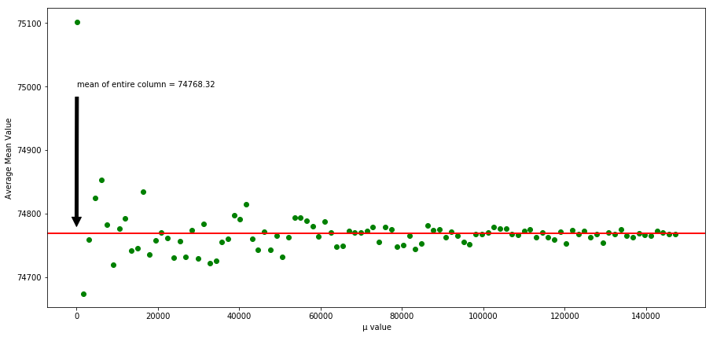

```python
plt.plot(mu_vector,mu_vector_mean,'go')
plt.axhline(y=mean, xmin=0, xmax=1,lw=2,c="red")
plt.annotate('mean of entire column = 74768.32', xy=(0, 74768), xytext=(100, 75000),
            arrowprops=dict(facecolor='black', shrink=0.05),
            )
plt.ylabel('Average Mean Value')
plt.xlabel(' μ value')
plt.show()
```

**Observation:** This plot shows that as the value of μ increases and gets close to the number of total number of rows in the column. The average mean gets close to the mean of entire column. This is because the sample size picked from the gaussian will start getting closer to the number of total rows in the column. According to the law of large numbers as the sample size increases the sample mean gets close to the mean of the population.

Now looking at the convergence by just changing σ and keeping μ and m same.

```python
#Generating  σ values in the range of 100 to 100000 in a gap of 1000 mean is fixed at
n=len(salary['Id'])
sg_vector = np.arange(100,100000,1000)
mu=int(n/2)
sg_vector
```

```
array([  100,  1100,  2100,  3100,  4100,  5100,  6100,  7100,  8100,
        9100, 10100, 11100, 12100, 13100, 14100, 15100, 16100, 17100,
       18100, 19100, 20100, 21100, 22100, 23100, 24100, 25100, 26100,
       27100, 28100, 29100, 30100, 31100, 32100, 33100, 34100, 35100,
       36100, 37100, 38100, 39100, 40100, 41100, 42100, 43100, 44100,
       45100, 46100, 47100, 48100, 49100, 50100, 51100, 52100, 53100,
       54100, 55100, 56100, 57100, 58100, 59100, 60100, 61100, 62100,
       63100, 64100, 65100, 66100, 67100, 68100, 69100, 70100, 71100,
       72100, 73100, 74100, 75100, 76100, 77100, 78100, 79100, 80100,
       81100, 82100, 83100, 84100, 85100, 86100, 87100, 88100, 89100,
       90100, 91100, 92100, 93100, 94100, 95100, 96100, 97100, 98100, 99100])
```

```python
len(sg_vector)
```

```
100
```

```python
# Doing the sampling experiment for different values of σ
sg_vector_mean =[]
sample_size=[]
for sg in sg_vector:
    sampled_mean_vector = []
    for i in range(100):
        S= sg * np.random.randn() + mu
        S= math.ceil(S)
        if S > n:
            S=n
        elif S<= 0:
            S=1
        sample_size.append(S)
        sample =random.sample(range(n), int(S))
        sampleTotalPay = salary[salary['Id'].isin(sample)]
        sampleTotalPay = sampleTotalPay['TotalPay']
        sample_mean =float(sampleTotalPay.mean())
        sampled_mean_vector.append(sample_mean)
    average_mean =s.mean(sampled_mean_vector)
    sg_vector_mean.append(average_mean)
sg_vector_mean
```

```
[74760.48441235951,
 74770.06069893799,
 74776.04250496767,
 74761.98842068897,
 74772.26423373267,
 74754.20744315654,
 74770.89009255105,
 74781.52939762539,
 74771.36354509467,
 74764.49784959338,
 74788.45242013327,
 74764.79846577307,
 74766.16154030786,
 74746.17855010642,
 74752.16987586096,
 74776.89501007291,
 74783.77774888216,
 74757.29752363589,
 74762.60455233994,
 74768.0150545337,
 74761.19007414355,
 74755.33911873099,
 74777.25518906448,
 74774.4425911529,
 74754.6718000749,
 74794.24896598245,
 74772.58596449655,
 74785.1595422235,
 74770.79026809514,
 74947.27876006716,
 74794.47720325948,
 74745.57108065639,
 73901.74063567504,
 74974.76001497862,
 74773.73656124751,
 75173.4271099419,
 75030.0680344888,
 74718.53970175504,
 72944.0198705754,
 74981.56936196615,
```

[output cut: 45 more lines]

```
 72622.01404563629,
 74731.25193466677,
 74199.90591281076,
 72092.20221678406,
 77812.29820234244,
 75000.30002635939,
 75218.71661286791,
 76122.54378764408,
 77800.9059320756,
 69478.57590467666,
 77134.87855738192,
 77952.07526716366,
 71913.1388471908,
 71052.41146765904,
 69977.67666962103]
```

```python
len(sample_size,range)
len(sg_vector_mean)
```

[output not shown]

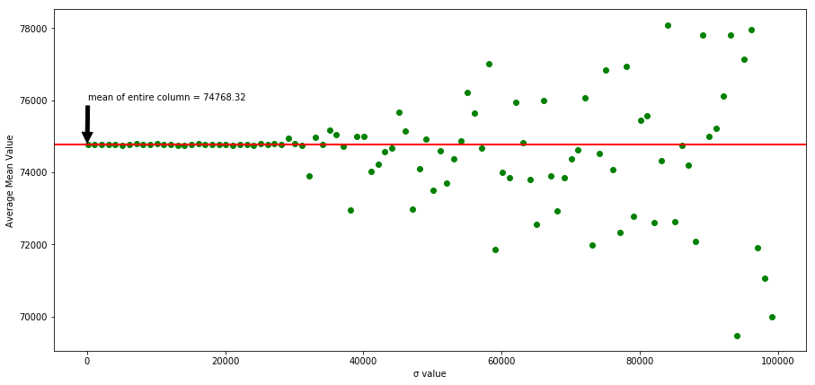

```python
plt.plot(sg_vector,sg_vector_mean,'go')
plt.axhline(y=mean, xmin=0, xmax=1,lw=2,c="red")
plt.annotate('mean of entire column = 74768.32', xy=(0, 74750), xytext=(100, 76000),
            arrowprops=dict(facecolor='black', shrink=0.05),
            )
plt.ylabel('Average Mean Value')
plt.xlabel('σ value')
plt.show()
```

Now for different values of m First we need to generate differnt values of m

```python
#Generating different values of m in the range of 1 to 1000 in a gap of 10 keeping μ=n/2 and σ=100 same for all the m
m_vector = np.arange(1,1000,150)
mu=int(n/2)
m_vector
```

```
array([  1, 151, 301, 451, 601, 751, 901])
```

```python
# Doing the sampling experiment for different values of m
m_vector_mean =[]
for m in m_vector:
    sampled_mean_vector = []
    for i in range(m):
        S= 100 * np.random.randn() + mu
        S= math.ceil(S)
        if S > n:
            S=n
        elif S<= 0:
            S=1
        sample =random.sample(range(n), int(S))
        sampleTotalPay = salary[salary['Id'].isin(sample)]
        sampleTotalPay = sampleTotalPay['TotalPay']
        sample_mean =float(sampleTotalPay.mean())
        sampled_mean_vector.append(sample_mean)
    average_mean =s.mean(sampled_mean_vector)
    m_vector_mean.append(average_mean)
m_vector_mean
```

```
[75163.31910073155,
 74773.51615436639,
 74758.6932392431,
 74770.74595616868,
 74761.60671943934,
 74753.0764543373,
 74766.23697039146]
```

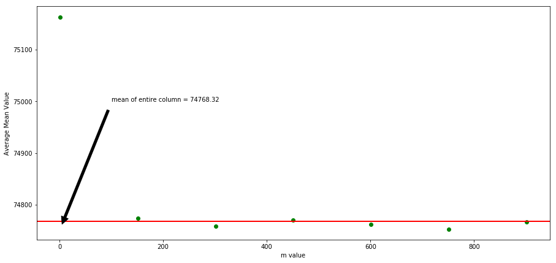

```python
plt.plot(m_vector,m_vector_mean,'go')
plt.axhline(y=mean, xmin=0, xmax=1,lw=2,c="red")
plt.annotate('mean of entire column = 74768.32', xy=(0, 74750), xytext=(100, 75000),
            arrowprops=dict(facecolor='black', shrink=0.05),
            )
plt.ylabel('Average Mean Value')
plt.xlabel('m value')
plt.show()
```

```python
#Generating different values of m in the range of 1 to 1000 in a gap of 10 keeping μ=n/2 and σ=100 same for all the m
m_vector2 = np.arange(1,200,5)
mu=int(n/2)
m_vector2
```

```
array([  1,   6,  11,  16,  21,  26,  31,  36,  41,  46,  51,  56,  61,
        66,  71,  76,  81,  86,  91,  96, 101, 106, 111, 116, 121, 126,
       131, 136, 141, 146, 151, 156, 161, 166, 171, 176, 181, 186, 191, 196])
```

```python
# Doing the sampling experiment for different values of m
m_vector_mean2 =[]
for m in m_vector2:
    sampled_mean_vector = []
    for i in range(m):
        S= 100 * np.random.randn() + mu
        S= math.ceil(S)
        if S > n:
            S=n
        elif S<= 0:
            S=1
        sample =random.sample(range(n), int(S))
        sampleTotalPay = salary[salary['Id'].isin(sample)]
        sampleTotalPay = sampleTotalPay['TotalPay']
        sample_mean =float(sampleTotalPay.mean())
        sampled_mean_vector.append(sample_mean)
    average_mean =s.mean(sampled_mean_vector)
    m_vector_mean2.append(average_mean)
m_vector_mean2
```

```
[75000.88403779767,
 74728.7838719126,
 74745.84452163345,
 74704.24283282885,
 74738.50605474436,
 74748.49736717303,
 74775.414573174,
 74812.91614612898,
 74773.78521138003,
 74780.69947486528,
 74776.9619437688,
 74793.06353533636,
 74779.05617995071,
 74782.93462339671,
 74771.94511345713,
 74792.33596021889,
 74777.68730058275,
 74760.73826473643,
 74755.68210710477,
 74781.57080759111,
 74766.75345444745,
 74762.42580888658,
 74785.24274017721,
 74773.79380364867,
 74765.97433945072,
 74770.21646364052,
 74783.91225615486,
 74770.44545560735,
 74759.27821578576,
 74788.03613580413,
 74755.78513886801,
 74761.84144199082,
 74762.29547323097,
 74775.24740388703,
 74748.40024681778,
 74773.00947860385,
 74757.87922715231,
 74772.60817238891,
 74767.11243505849,
 74765.39988135756]
```

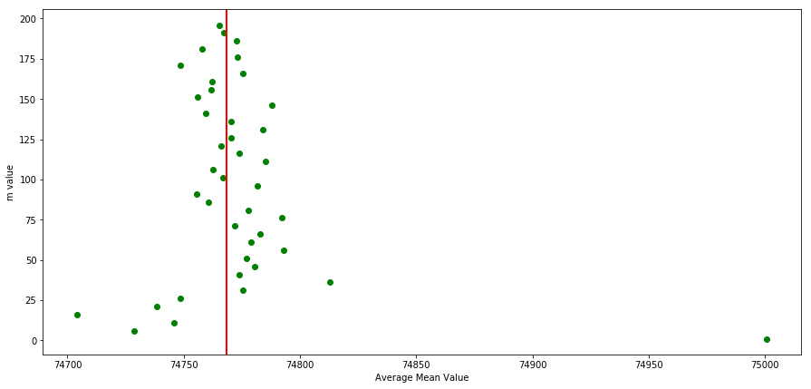

```python
plt.plot(m_vector_mean2,m_vector2,'go')
plt.axvline(x=mean, ymin=0, ymax=1,lw=2,c="red")
plt.xlabel('Average Mean Value')
plt.ylabel('m value')
plt.show()
```

**Observation:** Here we can see that as the value of m increases the sample mean gets close to the mean of entire column. This is because of central limit theorem which means the distribution of the average of a large number of independent, identically distributed variables will be approximately normal, regardless of the underlying distribution. Red line shows the mean of entire column.